# An introduction to Quarto

Literate programming for transparent research reporting

Janick Weberpals, RPh, PhD

jweberpals.academic@gmail.com

August 23, 2025

# Problem statement

> *Wait, but how was that done exactly?*

## Problem statement (i)

> *Wait, but how was that done exactly?*
- More often than not, statistical and computational methods are reported and phrased ambiguously, e.g.,

  > *“We measured the pre-exposure performance status within 90 days of the index date.”*
- Does the 90-day window include or exclude the index date? What was done if there were multiple performance assessments per patient? …
- Take a moment and reflect if you would be able to exactly reproduce a study you published 10 years ago just based on the paper’s methods section?

## Problem statement (ii)

> *Wait, but how was that done exactly?*

One could find the details in the analytical programming code, BUT…

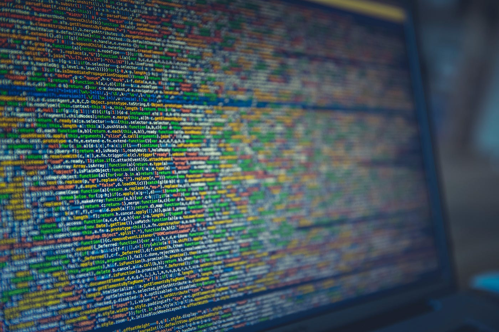

## Is there a reproducibility crisis?

[Nature survey 2016](https://www.nature.com/articles/533452a#change-history): More than 70% of researchers have tried and failed to reproduce another scientist’s experiments, and more than half have failed to reproduce their own experiments<sup>1</sup>

[figure not shown]

Figure 1: Nature survey on reproducibility issues in science.

## What if…

**What if…**

If there was just a way to combine…

- the narrative prose that explains the methods used
- the analytic code we implemented to execute these methods
- the corresponding results

…all in one report?

# Literate programming

> *Instead of imagining that our main task is to instruct a computer what to do, let us concentrate rather on explaining to human beings what we want a computer to do (*Donald Knuth, Turing Award recipient)

## Definition

It is basically an annotated, executable manuscript!

**Literate programming**

[Programming paradigm](https://en.wikipedia.org/wiki/Programming_paradigm) introduced in 1984 by [Donald Knuth](https://en.wikipedia.org/wiki/Donald_Knuth) in which a [computer program](https://en.wikipedia.org/wiki/Computer_program) is given as an explanation of how it works in a [natural language](https://en.wikipedia.org/wiki/Natural_language), such as English, interspersed (embedded) with snippets of macros and traditional [source code](https://en.wikipedia.org/wiki/Source_code), from which [compilable](https://en.wikipedia.org/wiki/Compiler) source code can be generated.

<sup>2</sup>

In other words…

$$\text{Literate programming} = \text{Documentation + Source Code + Output/Results}$$

## Example

**Methods section text:**

*“A propensity score model for exposure initiation was fit using logistic regression with age, sex and smoking as covariates. Patients were matched using nearest neighbor matching on the propensity score in a 1:1 ratio without replacement targeting the average treatment effect among the treated (ATT).”*

```r
MatchIt::matchit(
  formula = exposure ~ age_num + female_cat + smoking_cat,
  data = smdi::smdi_data,
  ratio = 1,
  method = "nearest",
  distance = "glm",
  link = "logit",
  estimand = "ATT",
  replace = F
  )
```

```
A `matchit` object
 - method: 1:1 nearest neighbor matching without replacement
 - distance: Propensity score
             - estimated with logistic regression
 - number of obs.: 2500 (original), 1996 (matched)
 - target estimand: ATT
 - covariates: age_num, female_cat, smoking_cat
```

# Quarto

> Dynamic study reporting

## Introduction to Quarto

- Unifies the functionality of many tools, packages and open source platforms into a single consistent system
- Extends it with native support for a large number of open-source programming languages (R, Python, Julia, Stan, C++, etc.)
- Can be used with most common code editors (RStudio, Jupyter, VSCode, etc.)
- Proprietary programming languages (SAS, STATA) can also be integrated but require some additional setup
  - Additional resources for use of Quarto with [SAS](https://sassoftware.github.io/saspy/configuration.html#http) ([setup](https://www.harveyl888.com/outputs/quarto_02.html), [demo](https://www.harveyl888.com/outputs/quarto_02.html)) and [STATA](https://users.ssc.wisc.edu/~hemken/Stataworkshops/Statamarkdown/stata-and-r-markdown.html) can be found on the course website

## Goal: single source publishing

- Since Quarto is a single source reporting system, we are not constraint to only output one document type but multiple given the same source document
- Example: Manuscript written for a journal, we can also render it into a website

[figure not shown]

Figure 7: From raw code and text to an elegant research report using Quarto

## Quarto - ingredients for a research report (i)

- First we provide **metadata** about the project in a so called `YAML header` (Yet Another Markdown Language)
- Documentation on all YAML options can be found on https://quarto.org/docs/reference/

```yaml
---
title: "My RWE study report"
author: "Janick Weberpals"
date: last-modified
toc: true
code-fold: true
number-sections: true
bibliography: references.bib
csl: pharmacoepidemiology-and-drug-safety.csl
format:
  html: default
  docx: default
  pdf: default
---
```

## Quarto - ingredients for a research report (ii)

`Plain text`

- To describe objectives, methods (just like in a .docx document)
- Achieved via Markdown syntax
- ✅ Universal and reproducible formatting across output document types
- ❌ Syntax needs to be known (although many modern editors come with a GUI)

[figure not shown]

## Quarto - ingredients for a research report (iii)

- `Code chunks` make it possible to blend plain text, programming code and the corresponding output, e.g.,

  **Methods section text:**

  *“The propensity score was defined as the probability of each patient to initiate the exposure based on observed baseline covariates including age, sex and smoking.”*

Code chunk following description of propensity score model:

```r
# define the model fit
ps_fit <- as.formula(exposure ~ age_num + female_cat + smoking_cat)
ps_fit
```

```
exposure ~ age_num + female_cat + smoking_cat
```

## Quarto - ingredients for a research report (iii)

- `Code chunks` are not limited to one programming language, but can flexibly accommodate multiple in the same document
- Language is chosen by the `{}` parameter at the beginning of each code chunk, e.g., `R` (left) and `Python` (right)

````markdown
```{r}
# Load necessary libraries
library(dplyr)

# Set a random seed for reproducibility
set.seed(42)

# Simulate a dataset
n_patients <- 1000
data <- data.frame(
  patient_id = 1:n_patients,
  medication = sample(c('DrugX', 'DrugY'), n_patients, replace = T, prob = c(0.5, 0.5)),
  adr = sample(c(0, 1), n_patients, replace = TRUE, prob = c(0.95, 0.05))
  )

# View the first few rows of the simulated data
head(data)
```
````

````markdown
```{python}
# Load necessary libraries
import pandas as pd
import numpy as np

# Set a random seed for reproducibility
np.random.seed(42)

# Simulate a dataset
n_patients = 1000
data = pd.DataFrame({
    'patient_id': np.arange(1, n_patients + 1),
    'medication': np.random.choice(['DrugX', 'DrugY'], size=n_patients, p=[0.5, 0.5]),
    'adr': np.random.choice([0, 1], size=n_patients, p=[0.95, 0.05])
    })

# View the first few rows of the simulated data
data.head()
```
````

# Reporting elements

## Figures

Quarto enables the integration, labeling and cross-referencing of `figures` using `@fig-missingness` which becomes Figure 8.

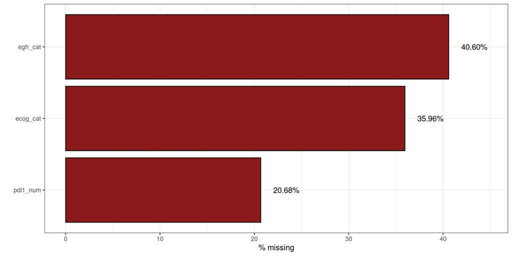

Figure 8: Proportion of missingness among covariates with at least one unobserved value

````markdown
```{r}
#| label: fig-missingness
#| fig-cap: "Proportion of missingness among covariates with at least one unobserved value"

library(smdi)

smdi_vis(smdi_data)
```
````

## Flowcharts and diagrams

- Quarto has native support for embedding [Mermaid](https://mermaid-js.github.io/mermaid/#/) and [Graphviz](https://graphviz.org/) diagrams
- This enables the depiction of flowcharts, sequence diagrams, state diagrams, gantt charts, and more using a plain text syntax inspired by markdown

````markdown
```{mermaid}
flowchart LR
  C(C) --> E(E)
  C(C) --> O(O)
  E(E) --> O(O)
```
````

```
flowchart LR
  C(C) --> E(E)
  C(C) --> O(O)
  E(E) --> O(O)
```

## Tables

We can also create, label and cross-reference `tables` using `@tbl-table1` which becomes Table 1.

````markdown
```{r}
#| label: tbl-table1
#| tbl-cap: "Baseline patient characteristics."

library(gtsummary)

trial |>
  tbl_summary(by = trt, include = c(age, grade))
```
````

Table 1: Baseline patient characteristics.

| **Characteristic** | **Drug A** N = 98 | **Drug B** N = 102 |
| --- | --- | --- |
| Age, Median (IQR) | 46 (37 – 60) | 48 (39 – 56) |
| Unknown | 7 | 4 |
| Grade, n (%) |  |  |
| I | 35 (36) | 33 (32) |
| II | 32 (33) | 36 (35) |
| III | 31 (32) | 33 (32) |

## Equations

- Quarto also integrates $\LaTeX{}$ and styles to write equations, for example …

```
$$
\lambda(t | X) = \lambda_0(t) \exp(\beta_1 X_1 + \beta_2 X_2 + \dots + \beta_p X_p)
$$
```

… becomes:

$$\lambda(t | X) = \lambda_0(t) \exp(\beta_1 X_1 + \beta_2 X_2 + \dots + \beta_p X_p)$$

## Referencing

Quarto has an in-built referencing system for which the referencing style can be chosen in the `YAML header` (.csl reference-style files see zotero.org/styles)

[figure not shown]

Figure 9: RStudio built-in reference manager

```yaml
---
title: "My RWE study report"
bibliography: references.bib
csl: pharmacoepidemiology-and-drug-safety.csl
format: docx
---

In the 2009 publication, Schneeweiss et al.
[@schneeweiss2009high] introduced the
concept of high-dimensional propensity scores.
```

## Inline code

- Inline code allows to execute code within markdown text, e.g. to automatically use the most up-to-date computations embedded in narrative language.

````markdown
```{r}
# we determine the sample size in a code chunk to integrate into our narrative report
sample_size <- nrow(smdi_data)
```

The sample size comprised `r sample_size` patients.
````

- In a dynamic study report, we now don’t need to manually copy-paste numbers, but only reference the resulting object of the computations performed in the code chunk, which then automatically shows the most-up-to date number:

> The sample size comprised 2500 patients.

# Interactive reports

If we render study reports to output formats that support interactive elements (e.g., .html), Quarto provides even more tools to make study reporting interactive

## Tabsets

- Tabset
- Age distribution
- Biomarker distribution

`Tabset` allows us to divide content into multiple tabs for interactive exploration

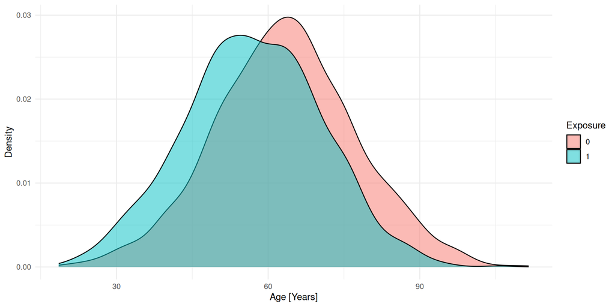

Figure 10: Age by exposure status

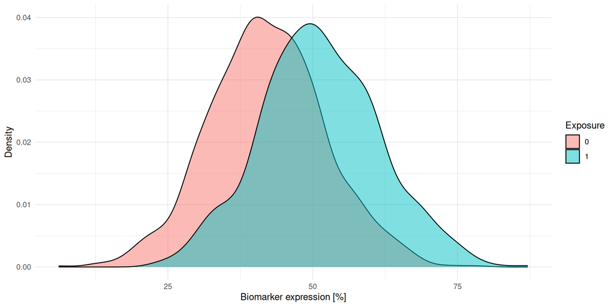

Figure 11: Biomarker expression by exposure status

```markdown
::: panel-tabset

## Age distribution

{code}

## Biomarker distribution

{code}

:::
```

## Code folding

Sometimes it may not be desired to see the entire code to enable readers to focus on the text and results but still have the ability to see the code

- `code-fold` parameter
- Output

```markdown
#| code-fold: true

library(ggplot2)

dataset |>
  ggplot(aes(x = exposure, y = age_num, fill = exposure)) +
  geom_boxplot(alpha = 0.5) +
  theme_minimal() +
  labs(
    x = "Exposure status",
    y = "Years of age",
    fill = "Exposure"
  )
```

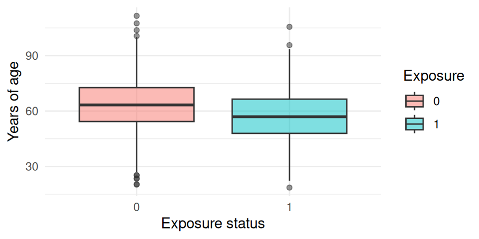

Figure 12: Age by exposure status

```r
library(ggplot2)

dataset |>
  ggplot(aes(x = exposure, y = age_num, fill = exposure)) +
  geom_boxplot(alpha = 0.5) +
  theme_minimal() +
  labs(
    x = "Exposure status",
    y = "Years of age",
    fill = "Exposure"
  )
```

## Parameterized reporting (i)

- RWE studies usually include many sensitivity analyses to check the robustness of certain assumptions and models in the main analysis
- Often it is just one or few parameters that have to bee changed
- Copy-pasting code back and forth is very error-prone and should be avoided

**Case study**

Let’s say we do propensity score matching with a certain caliper and want to run a sensitivity analysis with a different caliper but we don’t want to copy-paste any of the code

## Parameterized reporting (ii)

- The `YAML header` that contains the metadata about the study report also has an option to define study parameters that can be flexibly changed
- Let’s say we do propensity score matching with a certain caliper and want to run a sensitivity analysis with a different caliper

```yaml
---
title: "My RWE study report"
params:
  ps_caliper: 0.05
---
```

- The actual caliper is now replaced with `params$ps_caliper`

```r
MatchIt::matchit(
  formula = exposure ~ age_num + female_cat + smoking_cat,
  data = smdi::smdi_data,
  caliper = params$ps_caliper
  )
```

## Parameterized reporting (iii)

Now, the exact same script can be rendered using different parameters.

```r
# load libraries
library(quarto)
library(here)

# render report with parameters

# main analysis with 5% caliper of propensity score standard deviation
quarto_render(
  input =  "analysis.qmd",
  metadata = list(title = "Main analysis"),
  execute_params = list(ps_caliper = 0.05)
  )

# sensitivity analysis with 1% caliper of propensity score standard deviation
quarto_render(
  input =  "analysis.qmd",
  metadata = list(title = "Sensitivity analysis I"),
  execute_params = list(ps_caliper = 0.01)
  )
```

## Parameterized reporting (iv)

To render reports with parameters, you can also pass them on the command line/Terminal using the `-P` flag (this works for both `.ipynb` or `.qmd` files):

```
Terminal
```

```bash
quarto render analysis.qmd -P ps_caliper:0.05

quarto render analysis.qmd -P ps_caliper:0.01
```

## Quarto-based research reports (i)

**The ultimate goal…**

- reproduce your entire study, from deriving analytic cohorts to the very last sensitivity analysis, upon rendering your quarto project
- have access to all computations embedded in a manuscript text or linked research report

```
Terminal
```

```bash
quarto render
```

## Quarto-based research reports (ii)

[figure not shown]

Figure 13: An example of a Quarto-based research report can be found in the course materials website

## Quarto manuscripts

Quarto **manuscripts** (Quarto 1.4+), in addition to doing everything you can do with journal articles, can

- produce manuscripts in **multiple formats** (including LaTeX or MS Word formats required by journals), and give readers easy access to all of the formats through a website
- **publish computations** from one or more notebooks alongside the manuscript, allowing readers to dive into your code and view it or interact with it in a virtual environment
- Example of a reproduced NEJM trial<sup>4</sup>: https://mine-cetinkaya-rundel.github.io/indo-rct/

## Quarto manuscript templates

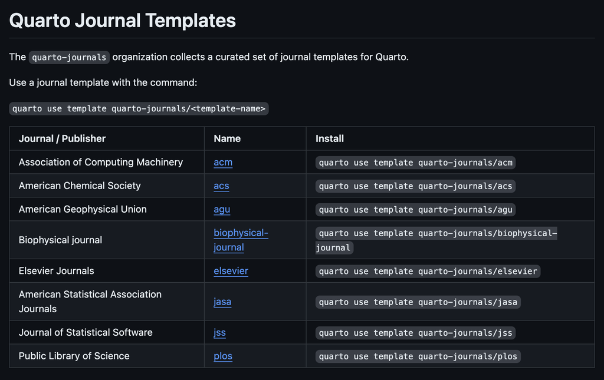

Figure 14: The quarto-journals organization collects a curated set of journal templates for Quarto.

## Quarto summary

**Quarto …**

- Is a technical publishing system compatible with most programming languages and editors
- Is a single source reporting system that can produce many different types of outputs (.docx, .pdf, .html, websites, presentations, etc.)
- Main ingredients: YAML header (metadata), text, code chunks
- Can be used as to blend narrative text, programming code and output in one document
- Has all capabilities of common reporting systems (e.g., MS Word) and many that go beyond (inline coding, dynamic and interactive elements, …)
- Is a useful tool to parameterize and streamline analysis pipelines avoiding error-prone copy-pasting

## Curious?

Test it out yourself with the `Hello, Quarto` tutorial:

https://quarto.org/docs/get-started/hello/rstudio.html

## **Further resources**

- [Getting started with Quarto (download and installation)](https://quarto.org/docs/get-started/)
- [Introduction to Quarto (R for Data Science)](https://r4ds.hadley.nz/quarto)
- [Basic Quarto workflows](https://openscapes.github.io/quarto-website-tutorial/quarto-workflows/)
- [Reproducible Manuscripts with Quarto](https://youtu.be/0wB4K08ui4c?si=VT35-wT9fyBBiFVj)

## Wrap up & Course evaluation

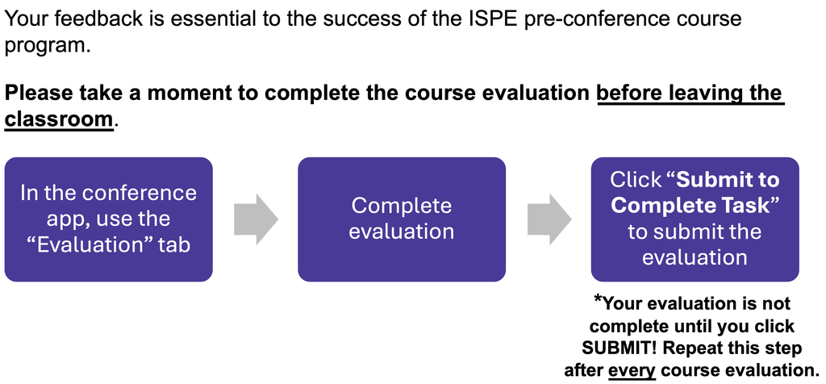

Figure 15: Instructions to complete the course eveluation in the conference app.

## **References**

1.

Baker M. 1,500 scientists lift the lid on reproducibility. *Nature* 2016; **533**: 452–454. doi:10.1038/533452a.

2.

Knuth DE. Literate programming. *The computer journal* 1984; **27**: 97–111.

3.

Schneeweiss S, Rassen JA, Glynn RJ, Avorn J, Mogun H, Brookhart MA. High-dimensional propensity score adjustment in studies of treatment effects using health care claims data. *Epidemiology* 2009; **20**: 512–522.

4.

Elmunzer BJ, Scheiman JM, Lehman GA, *et al.* A randomized trial of rectal indomethacin to prevent post-ERCP pancreatitis. *New England Journal of Medicine* 2012; **366**: 1414–1422.